# Self-Organizing Map for contingency tables

#### Laura BENDHAIBA, Madalina OLTEANU, Nathalie VILLA-VIALANEIX

## Basic package description

To be able to run the SOM algorithm, you have to load the package called `SOMbrero`. The function used to run it is called `trainSOM()` and is detailed below.

**This documentation only considers the case of contingency tables.**

### Arguments

The `trainSOM` function has several arguments, but only the first one is required. This argument is `x.data` which is the dataset used to train the SOM. In this documentation, it is passed to the function as a matrix or a data frame. This set must be a contingency table, i.e., it must contain either 0 or positive integers. Column and row names must be supplied.

The other arguments are the same as the arguments passed to the `initSOM` function (they are parameters defining the algorithm, see `help(initSOM)` for further details).

### Outputs

The `trainSOM` function returns an object of class `somRes` (see `help(trainSOM)` for further details on this class).

## Case study: the `presidentielles2002` data set

The `presidentielles2002` data set provides the number of votes at the first round of the 2002 French presidential election for each of the 16 candidates in all of the 106 French administrative districts called “departements”. Further details about this data set and the 2002 French presidential election are given with `help(presidentielles2002)`.

```r
data(presidentielles2002)
apply(presidentielles2002, 2, sum)
```

```
##      MEGRET      LEPAGE  GLUCKSTEIN      BAYROU      CHIRAC      LE_PEN
##      667043      535875      132696     1949219     5666021     4804772
##     TAUBIRA SAINT_JOSSE      MAMERE      JOSPIN      BOUTIN         HUE
##      660515     1204801     1495774     4610267      339157      960548
## CHEVENEMENT     MADELIN   LAGUILLER  BESANCENOT
##     1518568     1113551     1630118     1210562
```

(the two candidates that ran the second round of the election were Jacques Chirac and the far-right candidate Jean-Marie Le Pen)

### Training the SOM

```r
set.seed(4031719)
korresp.som <- trainSOM(x.data = presidentielles2002, dimension = c(8, 8), type = "korresp",
    scaling = "chi2", nb.save = 10)
korresp.som
```

```
##       Self-Organizing Map object...
##          online learning, type: korresp
##          8 x 8 grid with square topology
```

As the energy is registered during the intermediate backups, we can have a look at its evolution

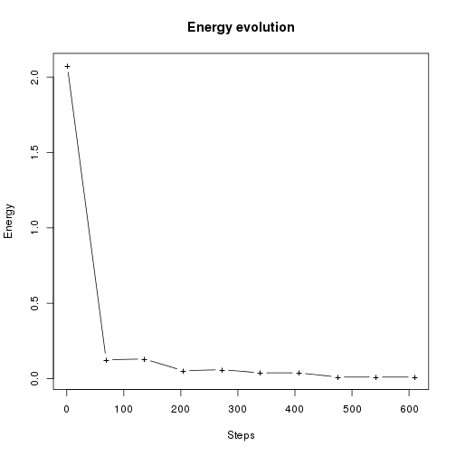

```r
plot(korresp.som, what = "energy")
```

which is stabilized during the last 100 iterations.

### Resulting clustering

The clustering component contains the final classification of the dataset. As both row and column variables are classified, the length of the resulting vector is equal to the sum of the number of rows and the number of columns.

**NB: The clustering component shows first the column variables (here, the candidates) and then the row variables (here, the departements).**

The following table indicates which graphics are available for a korresp SOM.

| Type | Energy | Obs | Prototypes | Add | Super Cluster |
| --- | --- | --- | --- | --- | --- |
| no type | x |  |  |  |  |
| hitmap |  | x |  |  | x |
| color |  |  | x2 |  | x2 |
| lines |  |  | x2 |  | x2 |
| barplot |  |  | x |  |  |
| radar |  |  | x |  |  |
| pie |  |  |  |  |  |
| boxplot |  |  |  |  |  |
| 3d |  |  | x2 |  |  |
| poly.dist |  |  | x |  | x |
| umatrix |  |  | x |  |  |
| smooth.dist |  |  | x |  |  |
| words |  |  |  |  |  |
| names |  | x |  |  |  |
| graph |  |  |  |  |  |
| mds |  |  | x |  | x |
| grid.dist |  |  | x |  |  |
| grid |  |  |  |  | x |
| dendrogram |  |  |  |  | x |
| dendro3d |  |  |  |  | x |

In the column “Prototypes”, a plot marked “x2” means that this plot is available for both row and column variables. In the “Super Cluster” column, a “x2” cell means the plot is available for both data set variables and additional variables.

```r
korresp.som$clustering
```

```
##                   MEGRET                   LEPAGE               GLUCKSTEIN
##                        8                        9                        5
##                   BAYROU                   CHIRAC                   LE_PEN
##                       25                       28                       24
##                  TAUBIRA              SAINT_JOSSE                   MAMERE
##                       57                       40                        9
##                   JOSPIN                   BOUTIN                      HUE
##                       46                        1                       15
##              CHEVENEMENT                  MADELIN                LAGUILLER
##                       59                        9                        5
##               BESANCENOT                      ain                    aisne
##                        5                        3                        4
##                   allier  alpes_de_haute_provence             hautes_alpes
##                       13                       32                       30
##          alpes_maritimes                  ardeche                 ardennes
##                        3                       32                        4
##                   ariege                     aube                     aude
##                       31                        4                       31
##                  aveyron         bouches_du_rhone                 calvados
##                       56                        8                       30
##                   cantal                 charente        charente_maritime
##                       64                       55                       56
##                     cher                  correze                corse_sud
##                       13                       63                       64
##              haute_corse                cote_d'or            cotes_d'armor
##                       64                       11                       21
##                   creuse                 dordogne                    doubs
##                       63                       55                       12
##                    drome                     eure             eure_et_loir
##                        3                        4                        4
##                finistere                     gard            haute_garonne
##                       21                       24                       22
##                     gers                  gironde                  herault
##                       39                       56                       24
##          ille_et_vilaine                    indre          indre_et_loire_
##                       29                       56                       20
##                    isere                     jura                   landes
##                       11                       12                       39
##             loir_et_cher                    loire              haute_loire
##                       32                        3                        3
```

[output cut: 27 more lines]

```
##                        3                       24                       29
##                   vienne             haute_vienne                   vosges
##                       55                       55                        4
##                    yonne    territoire_de_belfort                  essonne
##                        4                       12                       10
##          hauts_de_seine_        seine_saint-denis             val_de_marne
##                        1                       23                       10
##               val_d'oise               guadeloupe               martinique
##                       10                       57                       49
##                   guyane               la_reunion                  mayotte
##                       57                       45                       42
##       nouvelle_caledonie      polynesie_francaise saint_pierre_et_miquelon
##                       34                       41                       35
##         wallis_et_futuna   francais_de_l'etranger
##                       45                       52
```

The resulting distribution of the clustering on the map can also be visualized by a hitmap:

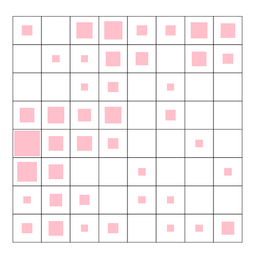

```r
plot(korresp.som, what = "obs", type = "hitmap")
```

For a more precise view, `"names"` plot is implemented: it prints, in each neuron, the names of the variables assigned to it ; in the korresp SOM, both row and column variable names are printed.

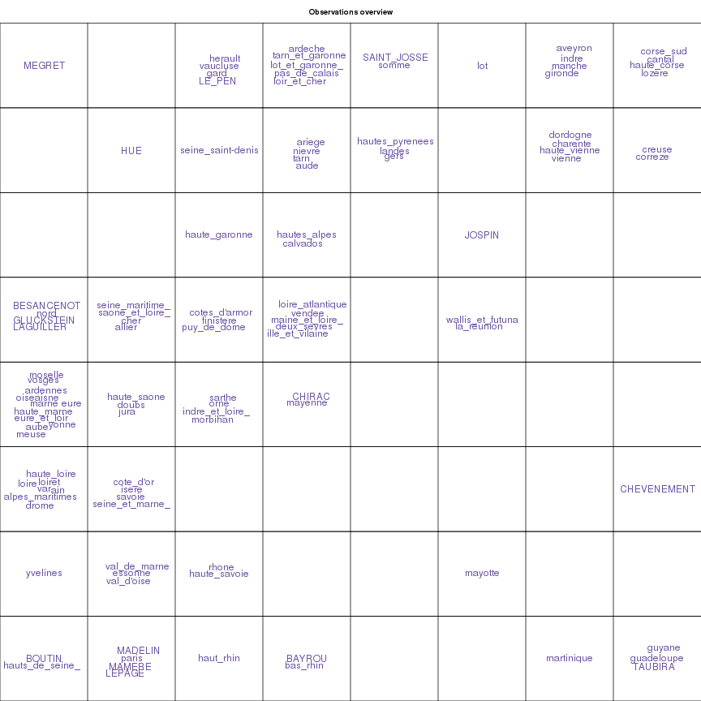

```r
plot(korresp.som, what = "obs", type = "names", scale = c(1.5, 0.5))
```

The map is organized as follows: the bottom right side of the map is associated to the candidate “Taubira” who obtained her better vote scoring in the overseas departements “Guadeloupe”, “Martinique” and “Guyane”.

### Clustering interpretation

Some graphics from the numeric SOM algorithm are still available in the korresp case. They are detailed below. As the resulting clustering provides the classification for both rows and columns, a new argument `view` is used to specify which one should be considered. Its possible values are either `"r"` for row variables (the default value) or `"c"` for column variables.

#### Graphics on prototype values

Three representations are available:

- with lines: either all row or all column variables are plotted (`view` argument is used)

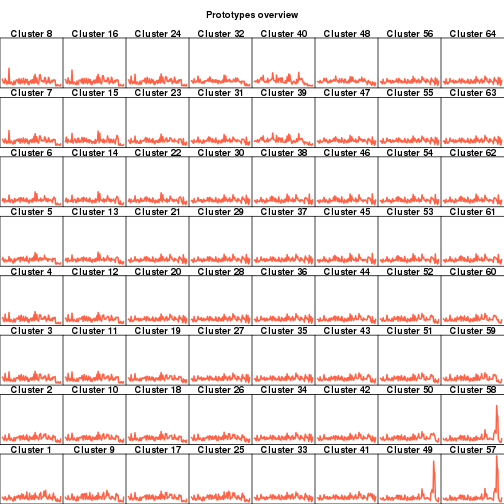

```r
# plot the line prototypes (106 French departements)
plot(korresp.som, what = "prototypes", type = "lines", view = "r", print.title = TRUE)
```

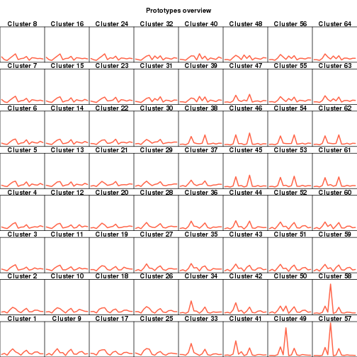

```r
# plot the column prototypes (16 candidates)
plot(korresp.som, what = "prototypes", type = "lines", view = "c", print.title = TRUE)
```

The peaks in neurons 49, 57 and 58 correspond, in the row view, to the overseas departement and, in the column view, to the candidate “Taubira”. In the column views, the two peaks clearly identified in the central clusters correspond to the two “main” tranditional candidates “Jospin” and “Chirac” (respectively, left and right candidates).

A more precise individual view are given with the graphics “color” and “3d”, here drawn, as an example for the candidate “Le Pen” and for the departement “Martinique”.

- in color: one of the row or column variable (the variable is chosen with the argument `variable`) is represented on the map;
- in 3d, which handling is similar to `"color"`.

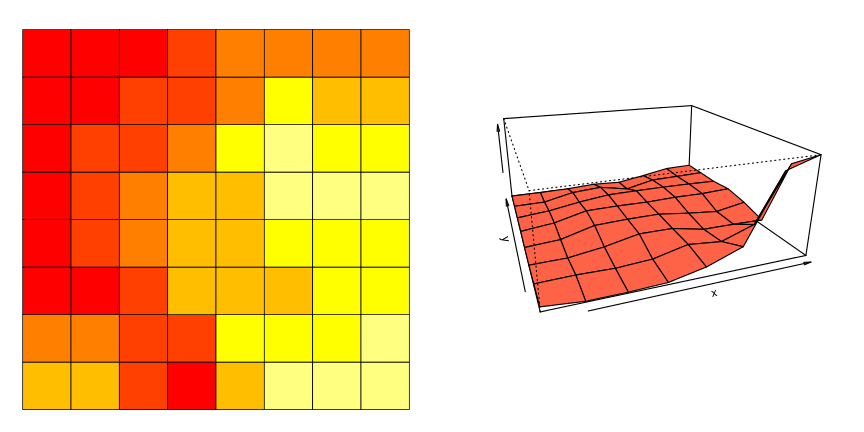

```r
par(mfrow = c(1, 2))
plot(korresp.som, what = "prototypes", type = "color", variable = "LE_PEN")
plot(korresp.som, what = "prototypes", type = "3d", variable = "martinique")
```

The second graphic shows that the candidates that obtained the higher scores in Martinique are located in the bottom right hand side of the map (mainly Taubira).

The graphics can also be drawn by giving the variable number and its type, either “r” or “c” (here, as an example, “Chirac” which is the 5th candidate):

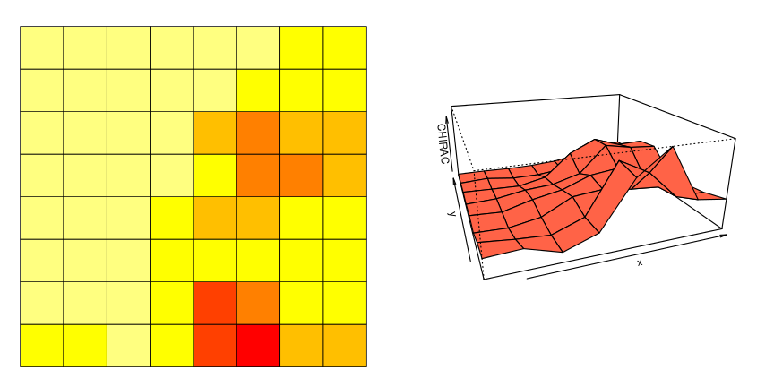

```r
par(mfrow = c(1, 2))
plot(korresp.som, what = "prototypes", type = "color", variable = 5, view = "c")
plot(korresp.som, what = "prototypes", type = "3d", variable = 5, view = "c")
```

Hence “Chirac” has a rather central position on the map which illustrates the fact that he is actually a “traditional” candidate with almost uniform votes in the whole country.

#### Graphic on prototype distances

These graphics are exactly the same as in the numerical case:

- `"poly.dist"` represents the distances between neighboring prototypes with polygons plotted for each cell of the grid. The smaller the distance between a polygon's vertex and a cell border, the closer the pair of prototypes. The colors indicates the number of observations in the neuron (white=empty);
- `"umatrix"` fills the neurons of the grid using colors that represent the average distance between the current prototype and its neighbors;
- `"smooth.dist"` plots the mean distance between the current prototype and its neighbors with a color gradation;
- `"mds"` plots the number of the neuron on a map according to a Multi Dimensional Scaling (MDS) projection;
- `"grid.dist"` plots a point for each pair of prototypes, with x coordinates representing the distance between the prototypes in the input space, and y coordinates representing the distance between the corresponding neurons on the grid.

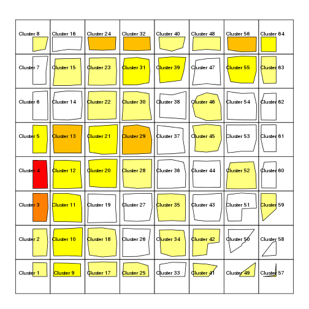

```r
plot(korresp.som, what = "prototypes", type = "poly.dist", print.title = TRUE)
```

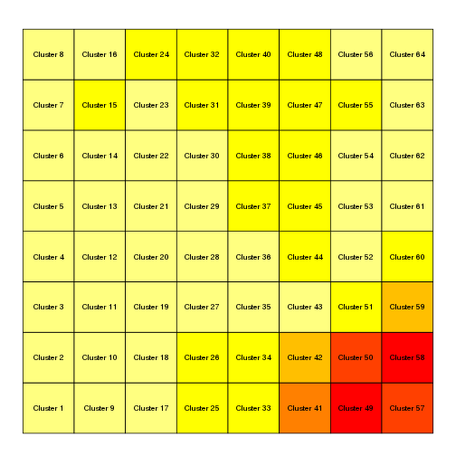

```r
plot(korresp.som, what = "prototypes", type = "umatrix", print.title = TRUE)
```

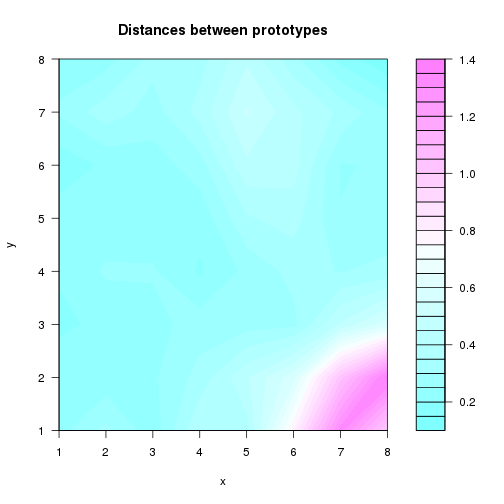

```r
plot(korresp.som, what = "prototypes", type = "smooth.dist", print.title = TRUE)
```

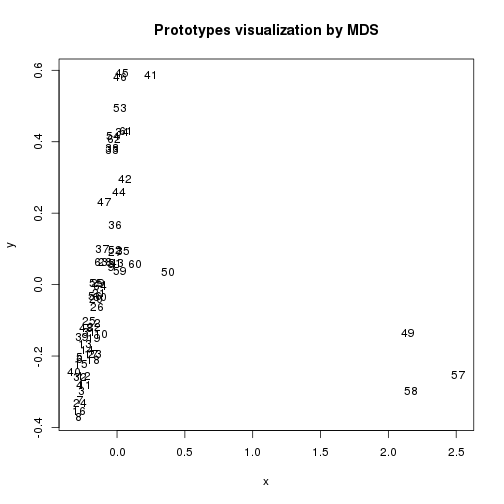

```r
plot(korresp.som, what = "prototypes", type = "mds")
```

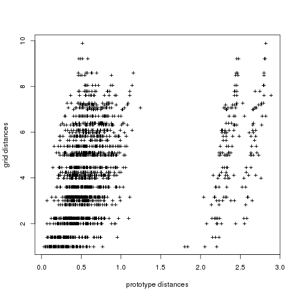

```r
plot(korresp.som, what = "prototypes", type = "grid.dist")
```

### Analyze the projection quality

```r
quality(korresp.som)
```

```
## $topographic
## [1] 0.1415
##
## $quantization
## [1] 0.03381
```

By default, the quality function calculates both quantization and topographic errors. It is also possible to specify which one you want to obtain, by using the argument `quality.type`.

The topographic error value varies between 0 (good projection quality) and 1 (poor projection quality). Here, the topographic quality of the mapping is quite good with a topographic error equal to 0.14.

The quantization error is an unbounded positive number. The closer from 0 it is, the better the projection quality is.

### Building super classes from the resulting SOM

In the SOM algorithm, the number of clusters is necessarily close to the number of neurons on the grid (not necessarily equal as some neurons may have no observations assigned to them). This - quite large - number may not suit the original data for a clustering purpose.

A usual way to address clustering with SOM is to perform a hierarchical clustering on the prototypes. This clustering is directly available in the package `SOMbrero` using the function `superClass`. To do so, you can first have a quick overview to decide on the number of super clusters which suits your data.

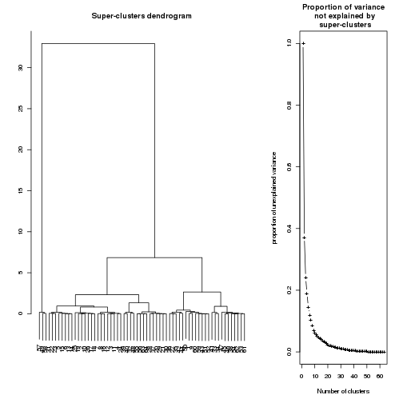

```r
plot(superClass(korresp.som))
```

By default, the function plots both a dendrogram and the evolution of the percentage of explained variance. Here, 3 super clusters seem to be a good choice. The output of `superClass` is a `somSC` class object. Basic functions have been defined for this class:

```r
my.sc <- superClass(korresp.som, k = 3)
summary(my.sc)
```

```
##
##    SOM Super Classes
##      Initial number of clusters :  64
##      Number of super clusters   :  3
##
##
##   Frequency table
##  1  2  3
## 24 37  3
##
##   Clustering
##  1  2  3  4  5  6  7  8  9 10 11 12 13 14 15 16 17 18 19 20 21 22 23 24 25
##  1  2  2  2  2  2  2  2  1  2  2  2  2  2  2  2  2  2  2  2  2  2  2  2  2
## 26 27 28 29 30 31 32 33 34 35 36 37 38 39 40 41 42 43 44 45 46 47 48 49 50
##  2  1  2  2  2  2  2  1  1  1  1  2  1  2  2  1  1  1  1  1  1  1  2  3  1
## 51 52 53 54 55 56 57 58 59 60 61 62 63 64
##  1  1  1  1  2  2  3  3  1  1  1  1  2  2
```

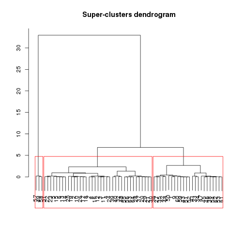

```r
plot(my.sc, plot.var = FALSE)
```

Like `plot.somRes`, the function `plot.somSC` has an argument `'type'` which offers many different plots and can thus be combined with most of the graphics produced by `plot.somSC`:

Case `"grid"` fills the grid with colors according to the super clustering (and can provide a legend). Case `"dendro3d"` plots a 3d dendrogram.

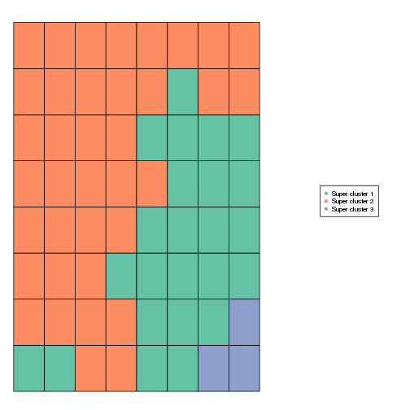

```r
plot(my.sc, type = "grid", plot.legend = TRUE)
```

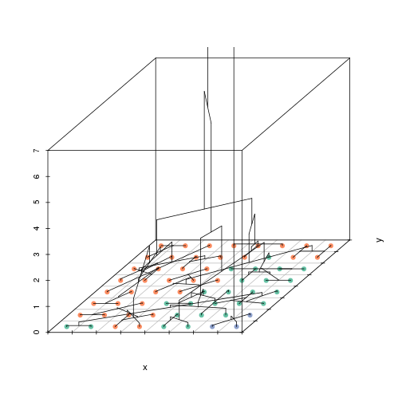

```r
plot(my.sc, type = "dendro3d")
```

The 3 different neurons mentionned earlier have been gathered together in the super cluster 3.

A couple of plots from `plot.somRes` are also available for the super clustering. Some identify the super clusters with colors:

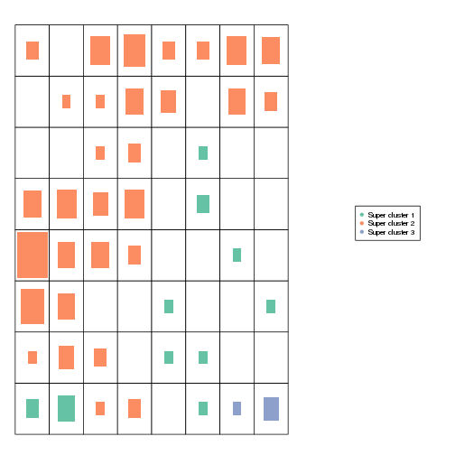

```r
plot(my.sc, type = "hitmap", plot.legend = TRUE)
```

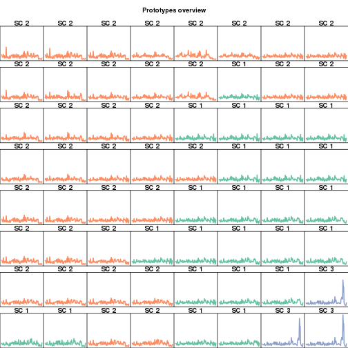

```r
plot(my.sc, type = "lines", print.title = TRUE)
```

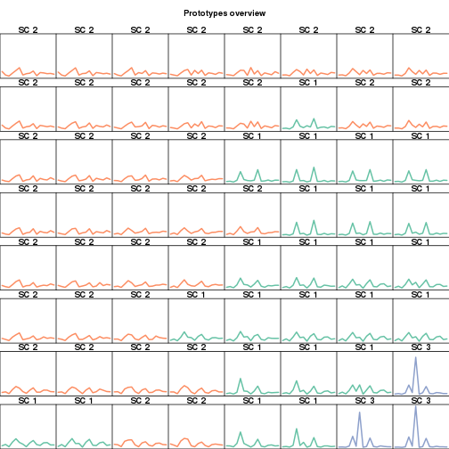

```r
plot(my.sc, type = "lines", print.title = TRUE, view = "c")
```

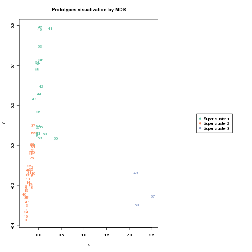

```r
plot(my.sc, type = "mds", plot.legend = TRUE)
```

And some others identify the super clusters with titles:

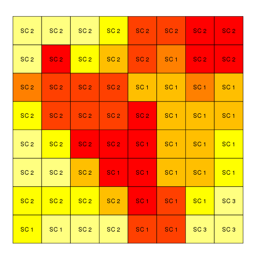

```r
plot(my.sc, type = "color", view = "r", variable = "correze")
```

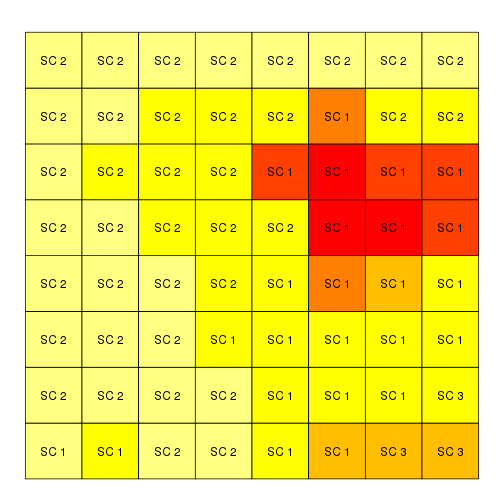

```r
plot(my.sc, type = "color", view = "c", variable = "JOSPIN")
```

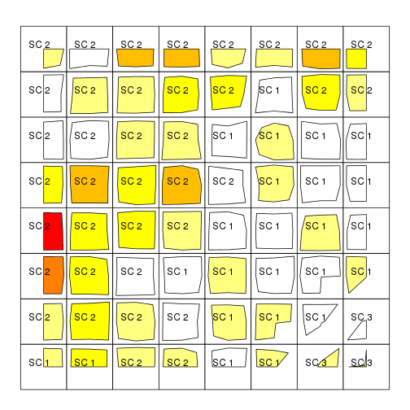

```r
plot(my.sc, type = "poly.dist")
```

Let us consider the third super cluster. It contains 3 departments and 1 candidate:

```
## [1] "TAUBIRA"    "guadeloupe" "martinique" "guyane"
```

The departments are the 3 biggest overseas departements. These departements, regarding history and culture, are different from metropolitan France thus they also have a different but common election behaviour. Particularly, during the 2002 French presidential election, they strongly promoted Christine Taubira, who is actually the candidate assigned to this super cluster, a woman originated from one of the overseas departements.